# Programming with Python- MBA 441B

# CIA 3_Exploratory Data Analysis

## Submitted By: LIKHITH S (1928616)

## Submitted To : Dr.Kannika Nirai Vaani

## Data chosen: House Sale Prices Data

[Click here for Link to Dataset: House Sales in King County, USA from Kaggle](https://www.kaggle.com/harlfoxem/housesalesprediction)

This data was acquired through Kaggle through its online portal. The data consists of information regarding the houses sold/bought in King County Region in the United States of America.

The objective of this work is to perform Exploratory Analysis on the data using Pandas to begin understanding using Python for Data Analysis.

### UNDERSTANDING THE BUSINESS & THE DATA AT HAND

The analysis dataset consists of prices of Houses in King County, Washington from sales.Along, with house price it consists of information on house features, ranging from date of Sale and ID of sale to the various attributes of the different houses, that can be considered as key selling points.

### Some salient points regarding the business and the business problem are,

Buying and selling of Real Estate and Housing in general are major drivers of a country’s economic growth

It is said that a growth of a country can be said by the rate at which construction activity occurs in it, A good example would be China’s practice over the last decades of constructing “GHOST CITIES” to artificially inflate the country’s economic growth figures.

There are more than two million real estate agents in the United States.

The median sales price for houses bought in September 2019 was $ 299,400.

701,000 new houses were sold in the United States this year.(VALUE= $210 BILLION!)

73% of realtors use digital platforms for their work.

### The Business Problem

Buying a house is commonly the most important financial transaction for the average person.

Most people buying houses are inexperienced amateurs with limited information about the market.

They tend to believe that prices will consistently rise, therefore, pay more than the house is worth.

In the US Market The mean expected rise in price was 38%. The actual rise in prices was 5.7%.

The fact that each transaction is negotiated individually creates an environment that results in an inefficient system.

### What is in our Data?

The variables in our data set and what they convey to us is listed below,

Id-Unique ID for each home sold

Date-Date of the home sale

Price-Price of each home sold

Bedrooms- Number of bed rooms

Bathrooms- Number of bathrooms, where .5 accounts for a room with a toilet but no shower

Sqft_living- Square footage of the apartments interior living space

Sqft_lot- Square footage of the land space

Floors- Number of ﬂoors

Waterfront-A variable for whether the apartment was overlooking a waterfront or not

View- An index from 0 to 4 of how good the view from the property is

Condition- An index from 1 to 5 on the condition of the apartment,

Grade- An index from 1 to 13, where 1-3 falls short of building construction and design, 7 has an average level of construction and design, and 11-13 have a high-quality level of construction and design

Sqft_above-The square footage of the interior housing space that is above ground level

Sqft_basement-The square footage of the interior housing space that is below ground level

Yr_built-The year the house was initially built

Yr_renovated -The year of the house’s last renovation

Zipcode-What zip code area the house is in, like pin code

Latitude, Latitude- coordinates of house location

Sqft_living15- The square footage of interior housing living space for the nearest 15 neighbors

Sqft_lotl5- The square footage of the land lots of the nearest 15 neighbors

### Having understood The Business in brief, we ca now proceed to our EDA using Python

```python
#Loading the libraries
# for linear algebra
# data processing

import numpy as np
import pandas as pd

# libraries for visualization
import seaborn as sns
import matplotlib.pyplot as plt
```

```python
# Importing Our Data

df=pd.read_csv("D:\\CU-MBA\\4TH-TRIMESTER\\PWP\\CIA3\\kc_house_data.csv")
df.head()
```

|  | id | date | price | bedrooms | bathrooms | sqft_living | sqft_lot | floors | waterfront | view | ... | grade | sqft_above | sqft_basement | yr_built | yr_renovated | zipcode | lat | long | sqft_living15 | sqft_lot15 |
| --- | --- | --- | --- | --- | --- | --- | --- | --- | --- | --- | --- | --- | --- | --- | --- | --- | --- | --- | --- | --- | --- |
| 0 | 7129300520 | 20141013T000000 | 221900.0 | 3 | 1.00 | 1180 | 5650 | 1.0 | 0 | 0 | ... | 7 | 1180 | 0 | 1955 | 0 | 98178 | 47.5112 | -122.257 | 1340 | 5650 |
| 1 | 6414100192 | 20141209T000000 | 538000.0 | 3 | 2.25 | 2570 | 7242 | 2.0 | 0 | 0 | ... | 7 | 2170 | 400 | 1951 | 1991 | 98125 | 47.7210 | -122.319 | 1690 | 7639 |
| 2 | 5631500400 | 20150225T000000 | 180000.0 | 2 | 1.00 | 770 | 10000 | 1.0 | 0 | 0 | ... | 6 | 770 | 0 | 1933 | 0 | 98028 | 47.7379 | -122.233 | 2720 | 8062 |
| 3 | 2487200875 | 20141209T000000 | 604000.0 | 4 | 3.00 | 1960 | 5000 | 1.0 | 0 | 0 | ... | 7 | 1050 | 910 | 1965 | 0 | 98136 | 47.5208 | -122.393 | 1360 | 5000 |
| 4 | 1954400510 | 20150218T000000 | 510000.0 | 3 | 2.00 | 1680 | 8080 | 1.0 | 0 | 0 | ... | 8 | 1680 | 0 | 1987 | 0 | 98074 | 47.6168 | -122.045 | 1800 | 7503 |

5 rows × 21 columns

```python
df.describe()
```

|  | id | price | bedrooms | bathrooms | sqft_living | sqft_lot | floors | waterfront | view | condition | grade | sqft_above | sqft_basement | yr_built | yr_renovated | zipcode | lat | long | sqft_living15 | sqft_lot15 |
| --- | --- | --- | --- | --- | --- | --- | --- | --- | --- | --- | --- | --- | --- | --- | --- | --- | --- | --- | --- | --- |
| count | 2.161300e+04 | 2.161300e+04 | 21613.000000 | 21613.000000 | 21613.000000 | 2.161300e+04 | 21613.000000 | 21613.000000 | 21613.000000 | 21613.000000 | 21613.000000 | 21613.000000 | 21613.000000 | 21613.000000 | 21613.000000 | 21613.000000 | 21613.000000 | 21613.000000 | 21613.000000 | 21613.000000 |
| mean | 4.580302e+09 | 5.400881e+05 | 3.370842 | 2.114757 | 2079.899736 | 1.510697e+04 | 1.494309 | 0.007542 | 0.234303 | 3.409430 | 7.656873 | 1788.390691 | 291.509045 | 1971.005136 | 84.402258 | 98077.939805 | 47.560053 | -122.213896 | 1986.552492 | 12768.455652 |
| std | 2.876566e+09 | 3.671272e+05 | 0.930062 | 0.770163 | 918.440897 | 4.142051e+04 | 0.539989 | 0.086517 | 0.766318 | 0.650743 | 1.175459 | 828.090978 | 442.575043 | 29.373411 | 401.679240 | 53.505026 | 0.138564 | 0.140828 | 685.391304 | 27304.179631 |
| min | 1.000102e+06 | 7.500000e+04 | 0.000000 | 0.000000 | 290.000000 | 5.200000e+02 | 1.000000 | 0.000000 | 0.000000 | 1.000000 | 1.000000 | 290.000000 | 0.000000 | 1900.000000 | 0.000000 | 98001.000000 | 47.155900 | -122.519000 | 399.000000 | 651.000000 |
| 25% | 2.123049e+09 | 3.219500e+05 | 3.000000 | 1.750000 | 1427.000000 | 5.040000e+03 | 1.000000 | 0.000000 | 0.000000 | 3.000000 | 7.000000 | 1190.000000 | 0.000000 | 1951.000000 | 0.000000 | 98033.000000 | 47.471000 | -122.328000 | 1490.000000 | 5100.000000 |
| 50% | 3.904930e+09 | 4.500000e+05 | 3.000000 | 2.250000 | 1910.000000 | 7.618000e+03 | 1.500000 | 0.000000 | 0.000000 | 3.000000 | 7.000000 | 1560.000000 | 0.000000 | 1975.000000 | 0.000000 | 98065.000000 | 47.571800 | -122.230000 | 1840.000000 | 7620.000000 |
| 75% | 7.308900e+09 | 6.450000e+05 | 4.000000 | 2.500000 | 2550.000000 | 1.068800e+04 | 2.000000 | 0.000000 | 0.000000 | 4.000000 | 8.000000 | 2210.000000 | 560.000000 | 1997.000000 | 0.000000 | 98118.000000 | 47.678000 | -122.125000 | 2360.000000 | 10083.000000 |
| max | 9.900000e+09 | 7.700000e+06 | 33.000000 | 8.000000 | 13540.000000 | 1.651359e+06 | 3.500000 | 1.000000 | 4.000000 | 5.000000 | 13.000000 | 9410.000000 | 4820.000000 | 2015.000000 | 2015.000000 | 98199.000000 | 47.777600 | -121.315000 | 6210.000000 | 871200.000000 |

### This gave us the basic statistical description of our data

Some points we can note are, 1) The avg. price of house at King's County is $ 540088

[output not shown]

Many such useful insights can be gained by viewing this data.

### Going forward we Look at Data Preperation.

We begin by performing a check to see if the data has any missing values, and gain a description of all variables(colums) we are analysing,

```python
#Description of the columns and Checking fo any null values

df.isnull().sum()
```

```
id               0
date             0
price            0
bedrooms         0
bathrooms        0
sqft_living      0
sqft_lot         0
floors           0
waterfront       0
view             0
condition        0
grade            0
sqft_above       0
sqft_basement    0
yr_built         0
yr_renovated     0
zipcode          0
lat              0
long             0
sqft_living15    0
sqft_lot15       0
dtype: int64
```

```python
# view of the types of data at hand,

df.dtypes
```

```
id                 int64
date              object
price            float64
bedrooms           int64
bathrooms        float64
sqft_living        int64
sqft_lot           int64
floors           float64
waterfront         int64
view               int64
condition          int64
grade              int64
sqft_above         int64
sqft_basement      int64
yr_built           int64
yr_renovated       int64
zipcode            int64
lat              float64
long             float64
sqft_living15      int64
sqft_lot15         int64
dtype: object
```

```python
# The date is in a format that is unusable by us

clean_date = df.date.apply(lambda x: x.split('T')[0])
clean_date

# Replacing the date

df['date'] = clean_date
df.head()

# Convert date column to standard usable Pandas datetime format

df['date'] = pd.to_datetime(df['date'], format = '%Y/%m/%d')

df.head()
```

|  | id | date | price | bedrooms | bathrooms | sqft_living | sqft_lot | floors | waterfront | view | ... | grade | sqft_above | sqft_basement | yr_built | yr_renovated | zipcode | lat | long | sqft_living15 | sqft_lot15 |
| --- | --- | --- | --- | --- | --- | --- | --- | --- | --- | --- | --- | --- | --- | --- | --- | --- | --- | --- | --- | --- | --- |
| 0 | 7129300520 | 2014-10-13 | 221900.0 | 3 | 1.00 | 1180 | 5650 | 1.0 | 0 | 0 | ... | 7 | 1180 | 0 | 1955 | 0 | 98178 | 47.5112 | -122.257 | 1340 | 5650 |
| 1 | 6414100192 | 2014-12-09 | 538000.0 | 3 | 2.25 | 2570 | 7242 | 2.0 | 0 | 0 | ... | 7 | 2170 | 400 | 1951 | 1991 | 98125 | 47.7210 | -122.319 | 1690 | 7639 |
| 2 | 5631500400 | 2015-02-25 | 180000.0 | 2 | 1.00 | 770 | 10000 | 1.0 | 0 | 0 | ... | 6 | 770 | 0 | 1933 | 0 | 98028 | 47.7379 | -122.233 | 2720 | 8062 |
| 3 | 2487200875 | 2014-12-09 | 604000.0 | 4 | 3.00 | 1960 | 5000 | 1.0 | 0 | 0 | ... | 7 | 1050 | 910 | 1965 | 0 | 98136 | 47.5208 | -122.393 | 1360 | 5000 |
| 4 | 1954400510 | 2015-02-18 | 510000.0 | 3 | 2.00 | 1680 | 8080 | 1.0 | 0 | 0 | ... | 8 | 1680 | 0 | 1987 | 0 | 98074 | 47.6168 | -122.045 | 1800 | 7503 |

5 rows × 21 columns

The price values are not easy to undestand, converting their format

```python
df.price = df.price.astype(np.int64)

# viewing our data now,

df.head()
# we can proceed to EDA now
```

|  | id | date | price | bedrooms | bathrooms | sqft_living | sqft_lot | floors | waterfront | view | ... | grade | sqft_above | sqft_basement | yr_built | yr_renovated | zipcode | lat | long | sqft_living15 | sqft_lot15 |
| --- | --- | --- | --- | --- | --- | --- | --- | --- | --- | --- | --- | --- | --- | --- | --- | --- | --- | --- | --- | --- | --- |
| 0 | 7129300520 | 2014-10-13 | 221900 | 3 | 1.00 | 1180 | 5650 | 1.0 | 0 | 0 | ... | 7 | 1180 | 0 | 1955 | 0 | 98178 | 47.5112 | -122.257 | 1340 | 5650 |
| 1 | 6414100192 | 2014-12-09 | 538000 | 3 | 2.25 | 2570 | 7242 | 2.0 | 0 | 0 | ... | 7 | 2170 | 400 | 1951 | 1991 | 98125 | 47.7210 | -122.319 | 1690 | 7639 |
| 2 | 5631500400 | 2015-02-25 | 180000 | 2 | 1.00 | 770 | 10000 | 1.0 | 0 | 0 | ... | 6 | 770 | 0 | 1933 | 0 | 98028 | 47.7379 | -122.233 | 2720 | 8062 |
| 3 | 2487200875 | 2014-12-09 | 604000 | 4 | 3.00 | 1960 | 5000 | 1.0 | 0 | 0 | ... | 7 | 1050 | 910 | 1965 | 0 | 98136 | 47.5208 | -122.393 | 1360 | 5000 |
| 4 | 1954400510 | 2015-02-18 | 510000 | 3 | 2.00 | 1680 | 8080 | 1.0 | 0 | 0 | ... | 8 | 1680 | 0 | 1987 | 0 | 98074 | 47.6168 | -122.045 | 1800 | 7503 |

5 rows × 21 columns

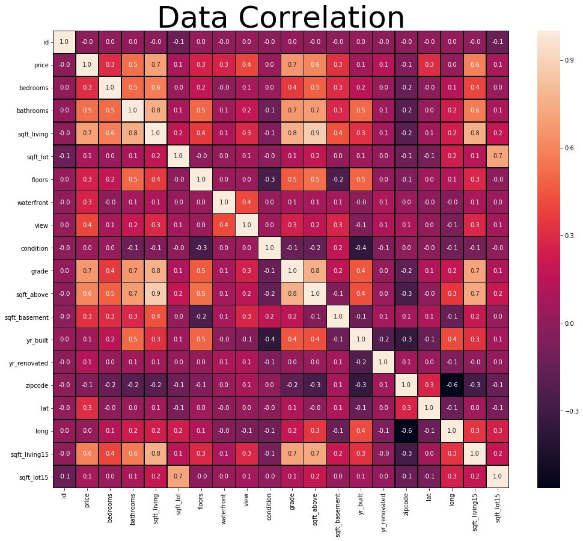

```python
### Our aim is to Check the variables that have the most effect on the column price
#We will make use of correlation plot with the variables

plt.subplots(figsize=(17,14))
sns.heatmap(df.corr(),annot=True,linewidths=0.5,linecolor="Black",fmt="1.1f")
plt.title("Data Correlation",fontsize=50)
plt.show()



#In this correlation matrix:

# In general there is a  positive relationship between price and other features.
# There is Just  is negative relationship between only few features
```

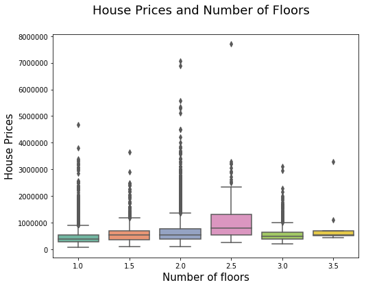

```python
# Floors in a House are very important factor in Price, we will use a box plot to understand it better

plt.figure(figsize=(8,6))
sns.boxplot(x = df['floors'], y=df['price'], palette="Set2")
plt.suptitle('House Prices and Number of Floors', size=18)
plt.xlabel('Number of floors', fontsize = 15)
plt.ylabel('House Prices', fontsize =15)

plt.show()
```

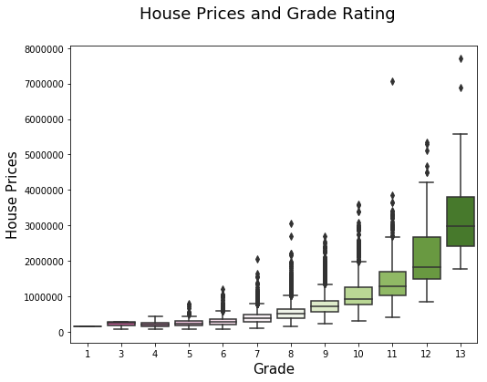

```python
#Grade of houses is another very important factor with high correlation, let us explore it further

plt.figure(figsize=(8,6))
sns.boxplot(x = df['grade'], y=df['price'], palette="PiYG")
plt.suptitle('House Prices and Grade Rating', size=18)
plt.xlabel('Grade', fontsize = 15)
plt.ylabel('House Prices', fontsize = 15)

plt.show()
```

There Appears to be a high relationship between Grade and Price. Significant increase in the price happens as the grade increases.

### With this information let us check the distribution of houses based on Grade in King County

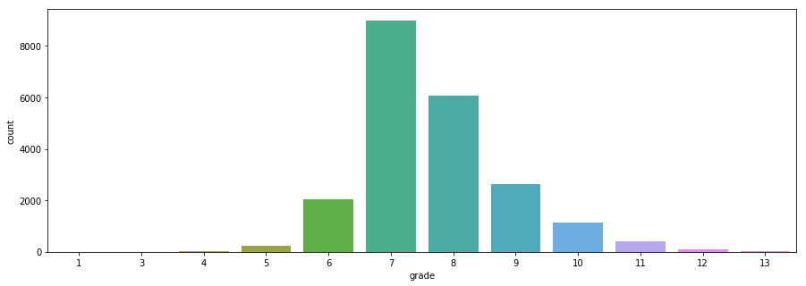

```python
# We are making use of a bar plot for this,

plt.subplots(figsize=(15, 5))
sns.countplot(df["grade"])
plt.show()
```

Most of the houses in King County have grade 7 and above!

### Building on this, let us go a step further and see the overall distribution of houses in King County, based on all the variables in our data

```python
# From the plot we can clearly see the distribution amonghst houses in King County
```

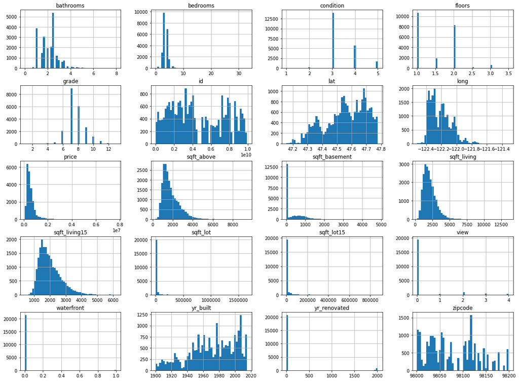

```python
%matplotlib inline
import matplotlib.pyplot as plt
df.hist(bins=50, figsize=(20,15))
plt.show()
```

```
price            1.000000
sqft_living      0.702035
grade            0.667434
sqft_above       0.605567
sqft_living15    0.585379
bathrooms        0.525138
view             0.397293
sqft_basement    0.323816
bedrooms         0.308350
lat              0.307003
waterfront       0.266369
floors           0.256794
yr_renovated     0.126434
sqft_lot         0.089661
sqft_lot15       0.082447
yr_built         0.054012
condition        0.036362
long             0.021626
id              -0.016762
zipcode         -0.053203
Name: price, dtype: float64
```

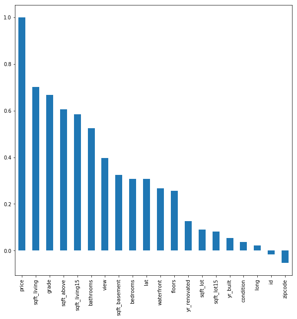

```python
# It was becoming very hard to hunt for the variables with highest degree of effect on price observing the correlation plot,
# So here are the variables arranged in descending order of their importance, represented in simple text and via a histogram

corr_matrix = df.corr()
plt.figure(figsize = (10,10))
s = corr_matrix['price'].sort_values(ascending = False)
print(s)
s.plot.bar()
```

### Bedrooms and Bathrooms are important features as expected, and shown by data

### Let us see what are the most popular bathroom and bedroom numbers a construction company should look at for high popularity of house

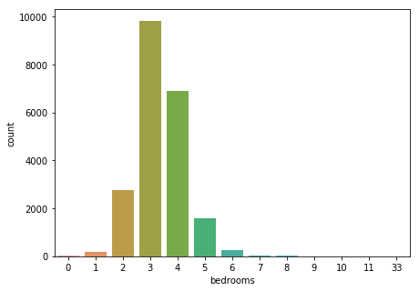

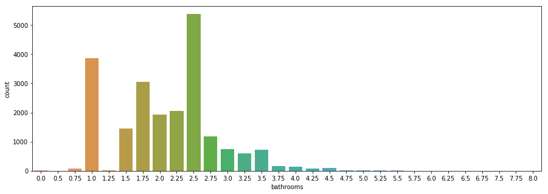

```python
plt.subplots(figsize=(7, 5))
sns.countplot(df["bedrooms"])
plt.show()

plt.subplots(figsize=(15, 5))
sns.countplot(df["bathrooms"])
plt.show()
```

### Property Developers should prefer atleast 3-4 bedrooms

### Single Bathroom and 2 bathrooms with an additional washroom(a common occurence in USA)(2.5 ) are the most popular.

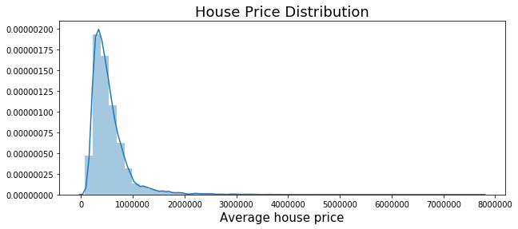

```python
#The last plot is this EDA exercise, demonstrtes the most important factor in houses,
#both for realtors and buyers that is PRICING!!

# A Distribution Plot is made use for this purpose

plt.figure(figsize=(10,4))
plt.title("House Price Distribution", size=18)
sns.distplot(df["price"])

plt.xlabel('Average house price', size=15)
plt.show()
```

### This brief exploratory data analysis gave us insight into the housing real estate sector industry and what goes on in it, of one particular region.

### It may be used by property developers to better understand the needs of the market with respect to what people need as features of their houses.

### THANKYOU! HAVE A NICE DAY.